# Final Project

Raymond Black

2023-06-03

# Introduction

Pharmacy is a diverse and rewarding profession that offers many opportunities for career advancement and personal growth. Pharmacists play a vital role in improving the health and well-being of patients and communities. As a pharmacy student, you may be wondering what some of the employment options for U.S. pharmacists are and how much they earn. In this presentation, we’ll explore some of the most common industries pharmacists work in, the average salaries for each industry, and the average salary per U.S. state.

Understanding the current trends of pharmacist salaries and employment options can help you plan ahead and prepare for the competitive job market. Knowing the anticipated salary can also help you to negotiate a compensation and benefits packages with potential employers after you graduate.

## Dataset Background Information

Data for this presentation is based on a sample of 830 occupational employment categories and wage estimates published by the US Bureau of Labor Statistics in May 2021 . The dataset consists of national, state, and select metropolitan/non-metropolitan area employment and wage estimates. Wage estimates are based on gross pay, excluding overtime pay, severance pay, shift differentials, non-production bonuses, employer cost for supplementary benefits, and tuition reimbursements.

The information in the data set is based on survey data collected between November 2018 and May 2021. BLS funds the survey and State Workforce Agencies collect the data by Internet, mail, email, telephone, or personal visit from approximately 1.1 million establishments. It’s estimated the May 2021 estimates used for this analysis are representative of about 62 percent of total U.S. employment.

## Citation

Bureau of Labor Statistics. (2021) Occupational Employment and Wage Statistics (OEWS) Survey (National) [Data set]. BLS. https://www.bls.gov/oes/special-requests/oesm21nat.zip

# Employment Overview

## U.S. Pharmacist Employment Estimates

As you already know, pharmacists are licensed health professionals who can work in various settings. You’re probably already familiar with employment opportunities in community pharmacies and hospitals, since these are the most common employers for pharmacists. However, there are many other settings pharmacists work in such as ambulatory clinics, long-term care facilities, pharmaceutical companies, academia, research, and government agencies.

According to the Bureau of Labor Statistics (BLS), there were 312,550 pharmacists employed in the U.S. as of May 2021.

This map shows the proportion of jobs for pharmacists per 1,000 jobs in each state. The darker the color, the higher the proportion of pharmacist jobs. As you can see, the 5 states with the highest proportion of pharmacists are West Virginia, South Dakota, North Dakota, Alabama and Kentucky.

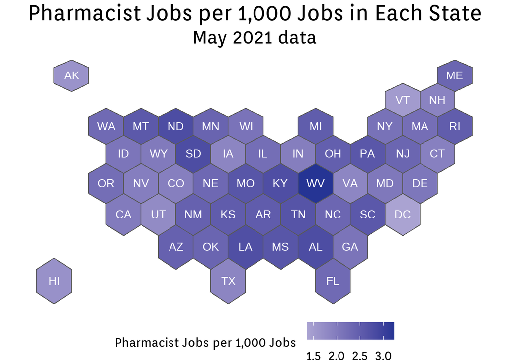

## Industries that Employ Pharmacists

There are many different industries that employ pharmacists in the US. There are the typical clinical settings like drug stores and hospitals where it’s common to wear a white coat and interact with patients, however we can also lose the white coat and work at a desk in government agencies or insurance companies.

This waffle chart shows the percentage of pharmacists who work in each industry. As you can see, the vast majority of pharmacists work in drug store pharmacies (40%) and hospitals (28%). This is interesting because there is quite a significant difference in both the level of training required for these 2 industries, as well as the annual salary, as you’ll see later in the presentation.

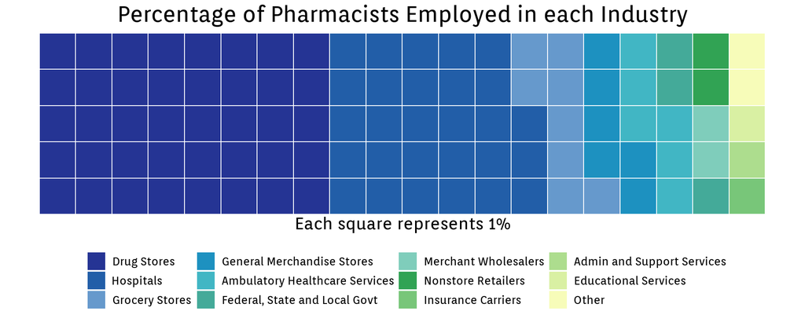

# Salary Statistics

## Average Annual Salary for U.S. Pharmacists

According to BLS data the average annual salary for U.S. pharmacists was $125,690 as of May 2021. However, pharmacists’ salaries vary widely depending on the geographic location and the industry of employment.

## Pharmacist Salary by State

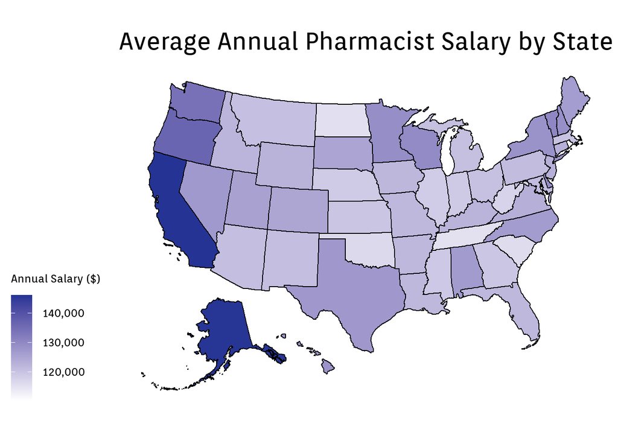

# Employment Options

As mentioned earlier, there are various types of employment settings for pharmacists in the U.S. The two most common settings are retail pharmacy and hospital pharmacy, which account for more than two-thirds of all pharmacist jobs. Of note, the term “retail pharmacy” includes multiple settings such as drug stores, general merchandise stores, and food and beverage stores.

Below you’ll find a chart that compares the average salary for pharmacists in a variety of settings. Notice the ~$14,000 difference in pay between drug stores, the most common retail setting, and hospitals. Pharmacists in drug stores earn less than the average cross-industry salary while hospital pharmacists earn more.

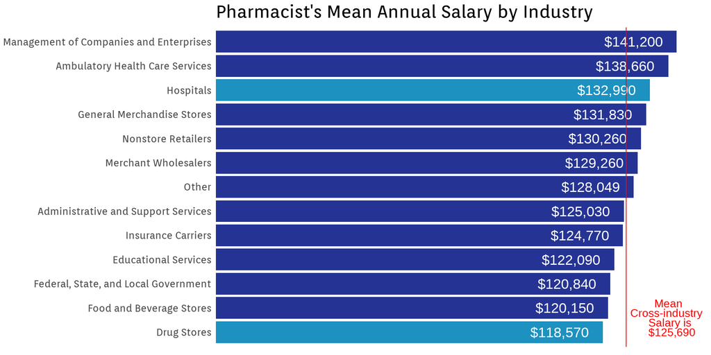

Let’s take a closer look at some of the employment settings available to pharmacists.

## Retail Pharmacy

Retail stores include drug stores, food and beverage stores, general merchandisers, and nonstore retailers (e.g. online pharmacies). Retail pharmacists dispense medications, counsel patients, provide immunizations and health screenings, and manage inventory and staff. Drug stores are the most common retailer and employed about 40% of all pharmacists with an average annual salary of $118,570 in 2021. Unlike almost any other pharmacy setting, there is no requirement to obtain a post-graduate education to work in retail pharmacy. Therefore you can begin earning a pharmacist’s salary immediately after graduating and becoming licensed.

## Hospital Pharmacy

Hospitals and health systems employ pharmacists in both inpatient and outpatient pharmacies. Hospital pharmacists prepare and dispense medications, monitor drug therapy, provide clinical services, educate patients and staff, and participate in research and quality improvement projects. Hospital pharmacists made up about 28% of all pharmacists in 2021, with an average annual salary of $132,990. But in order to work in a hospital, many employers will require you to complete a 1-2 year post-graduate educational program otherwise known as a residency. Pharmacy residents earn considerably less during their training, which means you won’t earn the hospital pharmacist’s salary listed in the above graphic until 1-2 years after graduating from pharmacy school. This is a trade-off you’ll need to consider before deciding to pursue a career in the hospital setting.

## Ambulatory Health Centers

Pharmacists working in ambulatory health centers, also known as outpatient clinics, provide medication therapy management and education to patients with chronic diseases. For example, they might monitor patients taking anticoagulation to ensure their therapy is effective or teach patients with asthma how to use their inhalers properly. They also collaborate with other healthcare professionals to ensure optimal patient outcomes and quality of care. Ambulatory care pharmacists accounted for 6% of the profession in 2021 and made $138,660 per year on average. Like hospital pharmacists, you’ll need to complete a 1-2 year post-graduate training program to specialize in this field.

## Pharmaceutical Industry

The Pharmaceutical industry is made up of pharmaceutical companies, biotechnology companies, contract research organizations, and regulatory agencies. Pharmacists employed in this setting are involved in research and development, clinical trials, drug information, medical affairs, regulatory affairs, marketing, sales, and education. This is an extremely specialized field and pharmaceutical industry post-graduate education programs are highly competitive. The average annual salary for pharmaceutical industry pharmacists was $125,060 in 2021. This average salary may not accurately reflect your earning potential because pharmaceutical industry workers often receive bonuses, and bonuses are excluded from the BLS wage estimates.

## Other settings

Pharmacists can also work in academic institutions, government agencies, community health centers, long-term care facilities, managed care organizations, consulting firms, and non-government organizations.

Common tasks for pharmacists in academia include teaching pharmacy students, conducting research projects, providing clinical services, and participating in faculty committees. Government agency pharmacists work in regulatory affairs or public policy at organizations like the Food and Drug Administration (FDA) or Centers for Disease Control (CDC). They are responsible for advising on legal and scientific requirements, and creating and enforcing regulations, guidelines, and laws for patient protection.

A registered pharmacist employed by a managed care organization is responsible for delivering prescription drug benefits to a large population of patients in a cost-effective way. Some of the specific tasks they perform include conducting drug utilization reviews for drug formulary management, implementing cost savings initiatives, and completing medication therapy management reviews.

# Conclusion

Pharmacists play a vital role in improving the health and well-being of patients and communities. While most pharmacists work in retail pharmacies like drug stores or food and beverage stores, we can also be employed by hospitals, outpatient clinics, universities, the pharmaceutical industry or even government agencies. The work environment can be fast-paced and demanding, but it can also be rewarding. The average annual salary for cross-industry pharmacists was $125,690 as of May 2021, but salaries vary depending on the geographic location and the industry of employment. If a higher salary is important to you, you should consider working in a general merchandise store, hospital, or ambulatory clinic. Do your research before settling on any particular industry though because many will require you to complete 1-2 years of post-graduate education, meaning you won’t earn the average salaries quoted in this presentation right away. I hope this information will help you to narrow down the list of options to those that help you to achieve your professional and financial goals.